# Question 8

Mandip Chaudhary (17)

## Data Creation and Preparation

```r
# Set seed using roll number 17
set.seed(17)

# Create dataset with 200 cases
n <- 200

# Create random variables
# Binary variable (0 and 1)
binary_var <- sample(c(0, 1), n, replace = TRUE)

# Continuous variables
continuous_var1 <- rnorm(n, mean = 50, sd = 10)
continuous_var2 <- runif(n, min = 0, max = 100)

# Categorical variables
categorical_var1 <- sample(c("A", "B", "C"), n, replace = TRUE)
categorical_var2 <- sample(c("Low", "Medium", "High"), n, replace = TRUE)

# Create data frame
data <- data.frame(
  binary_var = binary_var,
  continuous_var1 = continuous_var1,
  continuous_var2 = continuous_var2,
  categorical_var1 = categorical_var1,
  categorical_var2 = categorical_var2
)

# Convert categorical variables to factors
data$categorical_var1 <- as.factor(data$categorical_var1)
data$categorical_var2 <- as.factor(data$categorical_var2)

# Display first few rows of the dataset
head(data)
```

|  | binary_var | continuous_var1 | continuous_var2 | categorical_var1 | categorical_var2 |
| --- | --- | --- | --- | --- | --- |
| 1 | 1 | 50.43820 | 66.85459 | B | Low |
| 2 | 1 | 44.32008 | 37.39980 | B | Low |
| 3 | 0 | 68.24860 | 50.86067 | A | Low |
| 4 | 1 | 54.33003 | 24.29464 | A | Low |
| 5 | 1 | 36.46034 | 37.34355 | B | Medium |
| 6 | 0 | 61.54466 | 66.09521 | A | Low |

## Train-Test Split

```r
# Create train-test split (70:30)
set.seed(17)
train_index <- createDataPartition(data$binary_var, p = 0.7, list = FALSE)
train_data <- data[train_index, ]
test_data <- data[-train_index, ]

# Display dimensions of train and test sets
cat("Training set dimensions:", dim(train_data), "\n")
```

```
Training set dimensions: 140 5
```

```r
cat("Test set dimensions:", dim(test_data))
```

```
Test set dimensions: 60 5
```

## Model Fitting

### Logistic Regression Model

```r
# Fit logistic regression model
log_model <- glm(binary_var ~ ., data = train_data, family = "binomial")

# Summary of logistic regression model
summary(log_model)
```

```
Call:
glm(formula = binary_var ~ ., family = "binomial", data = train_data)

Coefficients:
                        Estimate Std. Error z value Pr(>|z|)
(Intercept)            -0.685200   0.952800  -0.719    0.472
continuous_var1         0.016964   0.017172   0.988    0.323
continuous_var2        -0.001547   0.006017  -0.257    0.797
categorical_var1B       0.042521   0.407632   0.104    0.917
categorical_var1C      -0.181689   0.432513  -0.420    0.674
categorical_var2Low    -0.430707   0.428753  -1.005    0.315
categorical_var2Medium -0.214895   0.408114  -0.527    0.599

(Dispersion parameter for binomial family taken to be 1)

    Null deviance: 193.37  on 139  degrees of freedom
Residual deviance: 191.25  on 133  degrees of freedom
AIC: 205.25

Number of Fisher Scoring iterations: 4
```

### Decision Tree Model

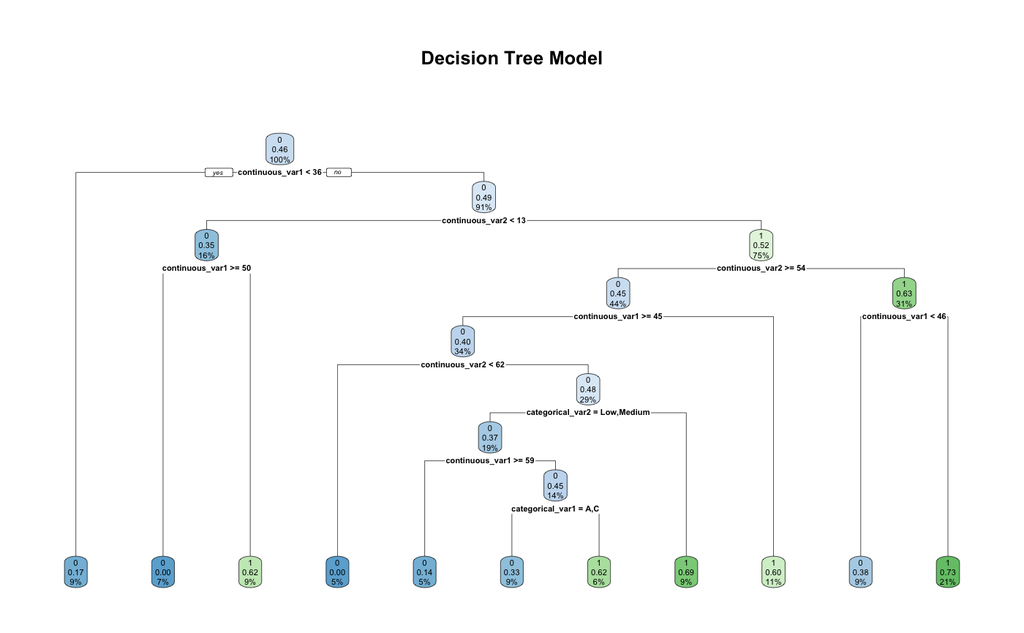

```r
# Fit decision tree model
tree_model <- rpart(binary_var ~ ., data = train_data, method = "class")

# Plot the decision tree
rpart.plot(tree_model, main = "Decision Tree Model")
```

## Model Predictions and Evaluation

```r
# Make predictions on test data
log_pred <- predict(log_model, newdata = test_data, type = "response")
log_pred_class <- ifelse(log_pred > 0.5, 1, 0)

tree_pred <- predict(tree_model, newdata = test_data, type = "class")

# Create confusion matrices
log_cm <- confusionMatrix(factor(log_pred_class), factor(test_data$binary_var))
tree_cm <- confusionMatrix(factor(tree_pred), factor(test_data$binary_var))

# Display confusion matrices
cat("Logistic Regression Confusion Matrix:\n")
```

```
Logistic Regression Confusion Matrix:
```

```r
print(log_cm$table)
```

```
          Reference
Prediction  0  1
         0 15 24
         1 12  9
```

```r
cat("\nDecision Tree Confusion Matrix:\n")
```

```
Decision Tree Confusion Matrix:
```

```r
print(tree_cm$table)
```

```
          Reference
Prediction  0  1
         0 12 15
         1 15 18
```

```r
# Display accuracy metrics
cat("\nLogistic Regression Accuracy:", log_cm$overall["Accuracy"])
```

```
Logistic Regression Accuracy: 0.4
```

```r
cat("\nDecision Tree Accuracy:", tree_cm$overall["Accuracy"])
```

```
Decision Tree Accuracy: 0.5
```

## Interpretation of Results

The analysis was performed using both logistic regression and decision tree classification models. Here’s the interpretation of the results:

1. **Data Creation**:
   - Created a dataset with 200 cases
   - Included one binary variable (0/1)
   - Two continuous variables (normally and uniformly distributed)
   - Two categorical variables (with 3 levels each)
2. **Train-Test Split**:
   - Data was split into 70% training (140 cases) and 30% testing (60 cases)
   - The split was performed using stratified sampling to maintain class distribution
3. **Model Performance**:
   - Both models were trained on the same training data
   - The logistic regression model provides probability estimates for the binary outcome
   - The decision tree model creates a hierarchical structure of decision rules
   - The confusion matrices show the prediction accuracy of both models
   - The accuracy metrics help compare the performance of both models
4. **Model Comparison**:
   - The logistic regression model provides a linear relationship between predictors and the outcome
   - The decision tree model can capture non-linear relationships and interactions
   - The accuracy metrics help determine which model performs better for this specific dataset

The results show how well each model predicts the binary outcome in the test dataset, allowing us to compare their performance and choose the more appropriate model for this classification task.